# LFMM analysis

Author

Juliette Archambeau

Published

April 28, 2023

# 1 Introduction

Document based on Gain and François (2021) and the [LEA tutorial](https://github.com/bcm-uga/SSMPG2022) provided during the summer school *Software and Statistical Methods for Population Genetics* ([SSMPG 2022](https://ssmpg.sciencesconf.org/); Aussois, September 19-23 2022).

The **latent factor mixed model** (LFMM) is a multivariate mixed regression model that estimates *simultaneously* the effects of environmental variables (fixed effects) and unobserved confounders called latent factors (Frichot et al. 2013; Caye et al. 2019). The latent factors are computed both from the genomes and from their environment. They are not representing neutral population structure (i.e. they have less direct interpretations than in ancestry estimation methods). Instead, they can be interpreted as the best estimates of the confounding effects of neutral population structure, leading to environmental effect size estimates with minimal bias.

# 2 Population structure

**COMMENT: this section is not used in the paper (=> can be skipped!).** Indeed, the analyses in this section are only useful if we want to estimate the population structure and impute missing data with the `LEA` package. In our study, we use the population structure estimates (the ancestry coefficients) from Jaramillo-Correa et al. (2015), and we impute the missing data based on the most common allele in the gene pool. And in the RDA, we do not use the ancestry coefficients to account for population structure; we use PC scores.

```r
geno <-  read.csv(here("data/DryadRepo/FormattedFilteredGenomicData_AlleleCounts_withmaf.csv")) %>%
  column_to_rownames("snp_ID") %>%
  dplyr::mutate(across(everything(), ~replace_na(.x, 9))) %>%
  t() %>%
  as.data.frame()

geno %>% write.geno(here("data/LEAanalysis/AlleleCounts_GenoFormat.geno"))

kable_mydf(geno[1:10,1:8], boldfirstcolumn = F)
```

[output not shown]

From Gain and François (2021):

Assuming $n$ diploid organisms genotyped at $L$ loci, the `snmf` algorithm decomposes the $n × L$ matrix of observed allele frequencies, $P$, in a product of two probabilistic matrices:

$$P \approx QF$$

where the coefficients of $P$ take their values in {0,1/2,1} for diploid organisms (note: ploidy can be modified in `snmf`). The matrix $Q$ is similar to the $Q$ matrix of STRUCTURE, representing ancestry coefficients for individuals originating from $K$ source populations (Pritchard, Stephens, and Donnelly 2000), and is a $n × K$ matrix. The matrix $F$ contains allele frequencies at each locus for each source population and is a $K × 3L$ matrix. While $P$ may contain some missing values, the product matrix, $QF$, is always a complete probabilistic matrix. $P$ is a $n × 3L$ matrix.

Comment: The matrix $F$ is called the matrix $G$ in the `LEA` package and in Frichot et al. (2013).

```r
proj_snmf <- snmf(here("data/LEAanalysis/AlleleCounts_GenoFormat.geno"),
                  K=1:10,
                  repetitions = 10, # nb of repetitions for each K
                  entropy = TRUE,
                  project="new")
```

```r
proj_snmf <- load.snmfProject(here("data/LEAanalysis/AlleleCounts_GenoFormat.snmfProject"))
```

We plot the cross-entropy criterion of all run of the project.

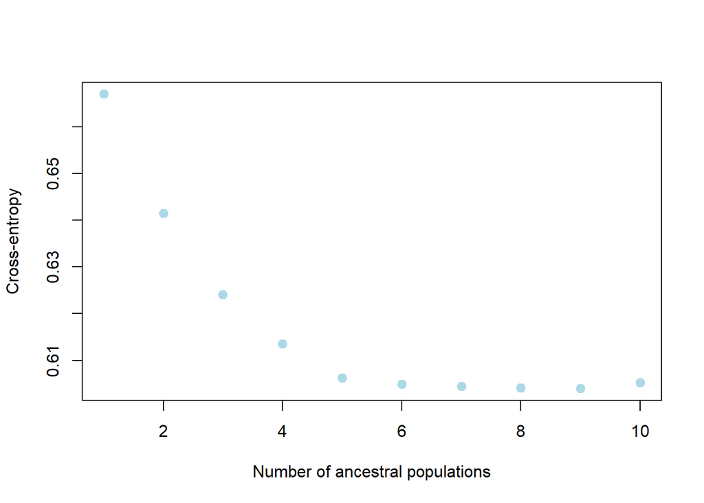

```r
plot(proj_snmf, cex = 1.2, col = "lightblue", pch = 19)
```

We get the cross-entropy of the 10 runs for K = 6 and we select the run with the lowest cross entropy

```r
ce <- cross.entropy(proj_snmf, K = 6)

best <- which.min(ce)
```

We display the Q-matrix.

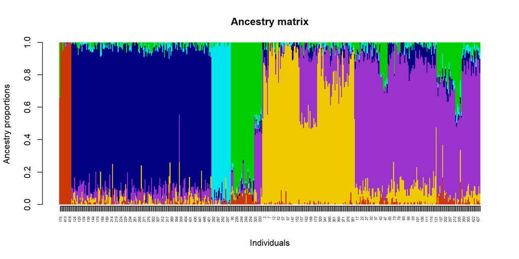

```r
gp_colors <- c("orangered3","gold2","darkorchid3","navyblue","turquoise2","green3") # define the colors of the gene pools

bp <- barchart(proj_snmf, K = 6,  run= best,
               border = NA, space = 0, col = gp_colors,
               xlab = "Individuals", ylab = "Ancestry proportions",
               main = "Ancestry matrix")

axis(1, at = 1:length(bp$order), labels = bp$order, las = 3, cex.axis = .4)
```

We use the `G` function to extract the **ancestral genotype frequency matrix**, $G$, for the 2nd run for K = 6.

```r
Gmatrix <- G(proj_snmf, K = 6, run = best)

Gmatrix[1:5,1:6] %>%
  as.data.frame() %>%
  kable_mydf(boldfirstcolumn = F)
```

| V1 | V2 | V3 | V4 | V5 | V6 |
| --- | --- | --- | --- | --- | --- |
| 0.43 | 1 | 1.0 | 1.00 | 1 | 1.00 |
| 0.49 | 0 | 0.0 | 0.00 | 0 | 0.00 |
| 0.08 | 0 | 0.0 | 0.00 | 0 | 0.00 |
| 0.08 | 1 | 0.7 | 0.68 | 1 | 0.33 |
| 0.37 | 0 | 0.3 | 0.28 | 0 | 0.50 |

# 3 Climatic data

We load the population-specific climatic information for the climatic variables of interest. To run `lfmm2`, individuals (genotypes in our case) have to be in rows and climatic variables in columns.

The past and future climatic data have been scaled with the parameters (mean and variance) of the past climatic data (which is done by the function `generate_clim_datatsets`).

```r
# Selected climatic variables
# ===========================
clim_var <- readRDS(here("data/ClimaticData/NamesSelectedVariables.rds"))


# Past and future climatic data
# =============================
source(here("scripts/functions/generate_clim_datasets.R"))
clim_dfs <- generate_clim_datasets(clim_var)
```

We attribute climatic values to each genotype, i.e. genotypes from the same populations will have the same climatic values.

```r
genotypes <- geno %>%
  rownames_to_column("clon") %>%
  dplyr::select(clon) %>%
  as_tibble()

clim_past <- genotypes %>%
  mutate(pop = str_sub(clon,1,3)) %>%
  left_join(clim_dfs$clim_past, by="pop") %>%
  dplyr::select(-pop,-clon)
```

# 4 Estimating gene-environment associations

## 4.1 Input data

### 4.1.1 Genomic data

We load the genomic data. The genomic has to be allele counts without missing data, with individuals (genotypes) in rows and SNPs in columns.

```r
# we load the imputed genomic data with allele counts (and without MAF)
geno <-  read.csv(here("data/DryadRepo/ImputedGenomicData_AlleleCounts_withoutmaf.csv")) %>%
  column_to_rownames("snp_ID") %>%
  t() %>%
  as_tibble()
```

## 4.2 Run lfmm2

From Caye et al. (2019): LFMMs are regression models combining fixed and latent effects as follows:

$$\mathbf{Y} = \mathbf{XB}^T + \mathbf{W} + \mathbf{E}$$

$\mathbf{Y}$ is the response matrix, which records data for $n$ individuals genotyped for $p$ genetic markers. $\mathbf{X}$ is the matrix of the *environmental* or *primary* variables. *Nuisance* variables such as observed confounders can be included in the $\mathbf{X}$ matrix, which dimension is then $n \times d$, where $d$ represents the total number of *primary* and *nuisance* variables. The fixed effect sizes are recorded in the $\mathbf{B}$ matrix, which has dimension $p \times d$. The $\mathbf{E}$ matrix represents residual errors, and it has the same dimensions as the response matrix. The matrix $\mathbf{W}$ is a “latent matrix” of rank $K$,defined by $K$ latent factors. The $K$ latent factors represent unobserved confounders which are modeled through an $n \times K$ matrix, $\mathbf{U}$.The matrix $\mathbf{U}$ is obtained from a singular value decomposition (SVD) of the matrix $\mathbf{W}$ as follows

$$\mathbf{W} = \mathbf{UV}^T$$

where $\mathbf{V}$ is a $p \times K$ matrix of loadings. The $\mathbf{U}$ and $\mathbf{V}$ matrices are unique up to arbitrary signs for the factors and loadings.

As there are 6 gene pools in maritime pine (all represented in our population sample), we run the LFMM model with **K=5**.

```r
mod_lfmm2 <- lfmm2(input = geno,
                   env = clim_past,
                   K = 5)
```

The function `lfmm2` returns an object of class `lfmm2Class` that contains the $\mathbf{U}$ and $\mathbf{V}$ matrices.

## 4.3 Calibration issues

With the function `lfmm2.test`, we can get a vector of p-values for association between loci and climatic variables adjusted for latent factors computed by `lfmm2`.

**The `full` option:**

- If `FALSE`, the function `lfmm2.test` computes significance values (p-values) from *standard Student tests* for each climatic variable.
- If `TRUE`, the function `lfmm2.test` returns p-values for the full set of climatic variables (a single value at each locus) using *Fisher tests*.

**The `genomic.control` option:**

- If `TRUE` (**default option**), the p-values are recalibrated by using genomic control after correction for confounding.
- If `FALSE`, the p-values are not recalibrated.

We can check if the p-values are well calibrated or not with the histograms of the p-values: ideally, they should be flat with a peak close to zero. in the two graphs below, we show the distribution of the non-calibrated (left graph) and calibrated (right graph) p-values. We can see that it is important to set the `genomic.control` to its default value `TRUE` if we want the p-values to be well calibrated.

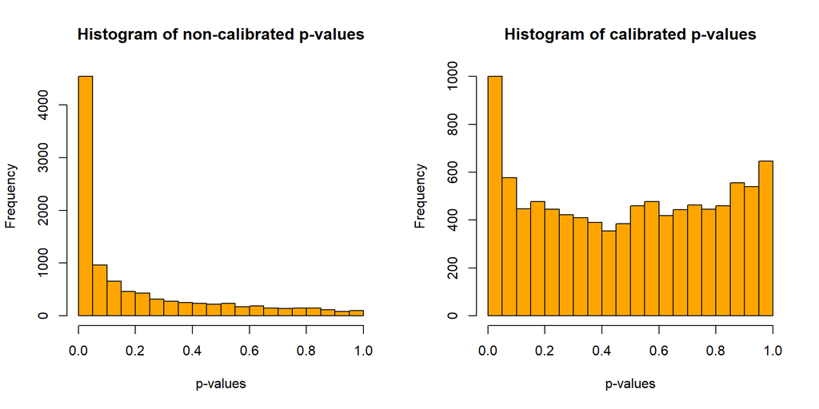

```r
par(mfrow=c(1,2))

# Histogram of non-calibrated p-values
# ------------------------------------
lfmm2.test(object = mod_lfmm2, input = geno, env = clim_past, full = TRUE, genomic.control = FALSE)$pvalues %>%
hist(col = "orange",
     main="Histogram of non-calibrated p-values",
     xlab="p-values")

# Histogram of calibrated p-values
# --------------------------------
lfmm2.test(object = mod_lfmm2, input = geno, env = clim_past, full = TRUE, genomic.control = TRUE)$pvalues %>%
hist(col = "orange",
     main="Histogram of calibrated p-values",
     xlab="p-values")
```

In the following analyses, we use the default `genomic.control=TRUE` and `full=TRUE`, so all climatic variables are used in the test.

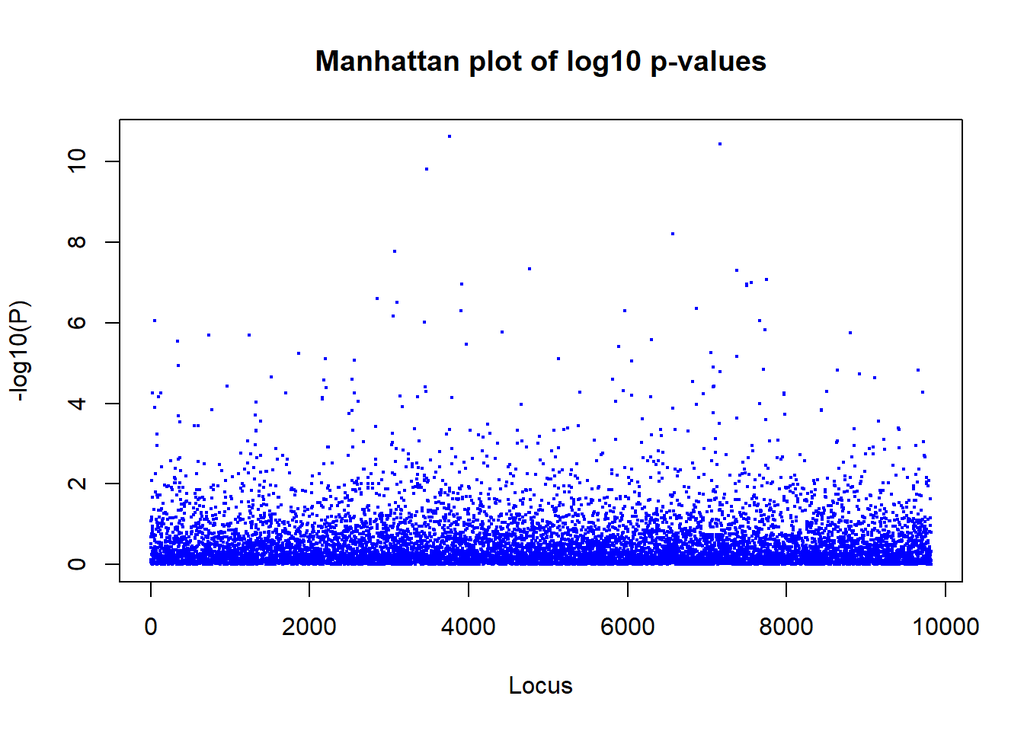

```r
test_lfmm2 <- lfmm2.test(object = mod_lfmm2,
                       input = geno,
                       env = clim_past,
                       full = TRUE,
                       genomic.control = TRUE)

pv_lfmm2 <- test_lfmm2$pvalues

plot(-log10(pv_lfmm2 ),
     cex = .3,
     col = "blue",
     xlab = "Locus",
     ylab = "-log10(P)",
     main="Manhattan plot of log10 p-values")
```

## 4.4 Multiple testing and calibration issues

We want to use the FDR control algorithm to correct for **multiple testing** and determine which loci have significant levels of association. The **False Discovery Rate (FDR)** is defined as:

**FDR = prob(False Discovery | Positive test) = *q***.

The FDR algorithm requires that the tests are correctly calibrated, i.e. that the distribution of p-values is uniform when we assume that the null hypothesis, $H0$, is correct. That’s ok in our case, we have already checked it above with the histogram of p-values.

**Which FDR level do we use?**

```r
fdr_level <- 0.1
```

To identify the candidate SNPs, we apply the chosen FDR control to the p-values, which converts them into q-values. And then we identify candidates as those with q-values below a given FDR threshold.

The candidate SNPs at the FDR level of 10% are shown with circles on the Manhattan plot below. The orange line corresponds to the Bonferroni threshold for a type I error of 10%.

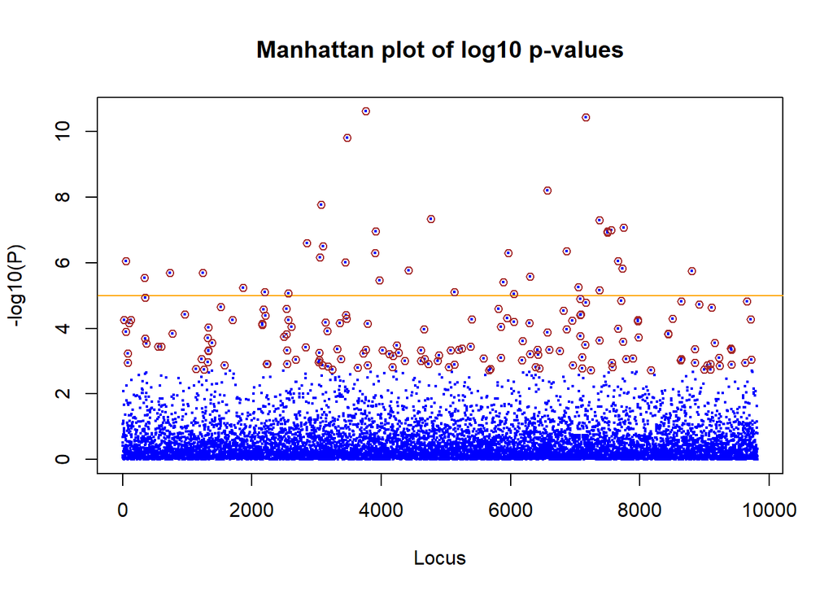

```r
# applying FDR control method to obtain q-values
qv_lfmm2  <- qvalue::qvalue(pv_lfmm2, fdr.level = fdr_level)

# Manhattan plot
plot(-log10(pv_lfmm2 ),
     cex = .3,
     col = "blue",
     xlab = "Locus",
     ylab = "-log10(P)",
     main="Manhattan plot of log10 p-values")

# Show with an orange line the Bonferonni multiple testing threshold for significance
abline(h = -log10(0.1/ncol(geno)), col = "orange")

# Extract the list of candidates
candidates <- which(qv_lfmm2$significant)

# Show with circles the list of candidate loci at the chosen FDR level
points(candidates, -log10(pv_lfmm2)[candidates], cex = .9, col = "brown")
```

```r
candidates <- names(geno)[candidates]

saveRDS(candidates, here("outputs/LFMM/candidates.rds"))
```

We obtain 188 candidate SNPs.

# 5 Estimating the genetic gap

This part is entirely based on the [LEA tutorial](https://github.com/bcm-uga/SSMPG2022/tree/master/Program%20tutorials/Tutorial%20LEA%203) provided during [SSMPG 2022](https://ssmpg.sciencesconf.org/).

Until now, methods to estimate the genomic offset has defined it as a **distance in the genetic space** (i.e. distance between allele frequencies). In the R packae `LEA`, the genomic offset is alternatively defined as a **distance in the environmental space**, i.e. measures of genomic offset are linked to the geometry of the ecological niche. This new definition of the genomic offset is referred as **genetic gap** and is implemented in the `genetic.gap` function of the `LEA` package.

The genetic gap is based on the estimates of environmental effect sizes obtained from an LFMM. The relationship inferred in the GEA is then used to fit and predict allelic variation at all genomic loci, alleviating the need for a set of candidate loci and the choice of a significance level.

Below, we will estimate the genetic gap for:

- the sets of candidate SNPs
- the control set of SNPs
- all SNPs (as advised by the developers of the `genetic.gap` function)

## 5.1 Future climatic data

We load the predicted values of the climatic variables for the years 2041-2070 that have been scaled (i.e. mean-center) with the same scaling parameters as the one used to mean-center the annual climatic values across the period 1901-1950.

```r
# Attribute climatic values for each genotype
list_g_gap <- lapply(clim_dfs[[2]], function(clim_fut){


df <- genotypes %>%
  mutate(pop = str_sub(clon,1,3)) %>%
  left_join(clim_fut, by="pop") %>%
  dplyr::select(-pop,-clon,-gcm)

list(gcm = unique(clim_fut$gcm),
     clim_fut = df)

})
```

## 5.2 Genetic gap estimation with all SNPs

We run the `genetic.gap` function.

```r
list_g_gap <- lapply(list_g_gap, function(x){

x$g_gap_allsnps <- genetic.gap(input = geno,
                               env = clim_past,
                               pred.env = x$clim_fut,
                               K = 5)

return(x)

})

list_g_gap[[1]]$g_gap_allsnp
```

[output not shown]

[output cut: 37 more lines]

The outputs of the `genetic.gap` function are (copy-and-pasted from the `LEA` manual):

- `offset`: a vector of **genomic offset** values computed for every sample location in `new.env` and `pred.env`. Note that the genomic offset is referred to as the *genetic gap* in Gain and François (2021) and the *geometric GO* in Gain et al. (2023).
- `distance`: a vector of **environmental distance** values computed for every sample location in `new.env` and `pred.env`. The distances to an estimate of the risk of nonadaptedness that includes correction for confounding factors and analyzes multiple predictors simultaneously (modified version of RONA).
- `eigenvalues`: eigenvalues of the covariance matrix of LFMM effect sizes. They represent the relative importance of combinations of environmental variables described in vectors when the environmental data have similar scales. To be used with `scale == TRUE`.
- `vectors`: eigenvectors of the covariance matrix of LFMM effect sizes representing combinations of environmental variables sorted by importance (eigenvalues).

### 5.2.1 Relationship with Euclidean climatic distance

In the supplementary information of Gain et al. (2023), the authors say that ‘If (and only if) the eigenvalues of the covariance matrix are equal, the geometric GO is proportional to the squared Euclidean distance between environmental predictors.’ Note that a variable $y$ *is proportional to* a variable $x$ if there is a non-zero constant $k$ such as $y = kx$.

In this part, we look at the relationship between the **squared root of the genetic gap** vs **the Euclidean climatic distance** (or the genetic gap and the squared Euclidean climatic distance).

The Euclidean climatic distance is calculated as follows:

$$D_{clim} = \sqrt{\sum_{i=1}^{N} (X_{past,i} - X_{fut,i})^2}$$

with $N$ the number of selected climatic variables, $X_{past,i}$ the mean value of the climatic variable $i$ across the period 1901-1950 and $X_{fut,i}$ the predicted mean value of the climatic variable $i$ across the period 2041-2070.

```r
# Calculate the Euclidean climatic distance
list_g_gap <- lapply(list_g_gap, function(x){

Delta = clim_past - x$clim_fut

x$dist_env = sqrt( rowSums(Delta^2) )

return(x)
})
```

```r
# Incorporating gene pool information
# -----------------------------------

# In the graphs below, we want to color the populations according to the main gene pool they belong to

# we load the main gene pool information for each clone
gps <- readRDS(here("data/GenomicData/MainGenePoolInformation.rds"))[[2]]
```

Correlation between the squared Euclidean climatic distance and the genetic gap (`offset` in the outputs):

```r
lapply(list_g_gap, function(y){

cor(unique(y$g_gap_allsnps$offset),unique(y$dist_env^2))

}) %>%
  bind_rows(.id="GCM") %>%
  kable_mydf()
```

| GFDL-ESM4 | IPSL-CM6A-LR | MPI-ESM1-2-HR | MRI-ESM2-0 | UKESM1-0-LL |
| --- | --- | --- | --- | --- |
| 0.84 | 0.87 | 0.91 | 0.84 | 0.83 |

Comment: The squared Euclidean climatic distance and the genetic gap are somewhat correlated (the strength of the correlation depending on whether we include or not the outlier pops), so it means that the genetic gap $GO$ can be expressed as follows: $GO = a \times dist^2 + b + e$ with $dist$ being the Euclidean climatic distance and the $e$ the residuals (ie the noise). **Note that $GO$ and $dist^2$ are correlated but not proportional to!**

We can plot the `eigenvalues` with a barplot to evaluate the relative importance of the climatic variables.

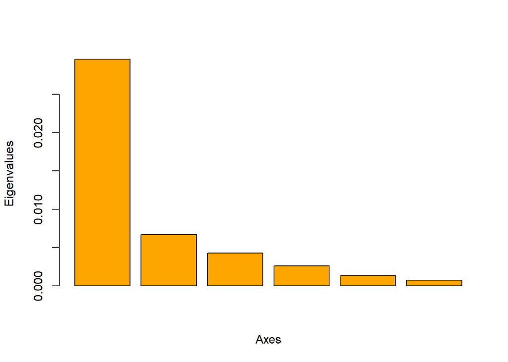

```r
# the relative importance is the same for all genomic offset predictions at it is only influenced by past climates, and not future climates
barplot(list_g_gap[[1]]$g_gap_allsnp$eigenvalues, col = "orange", xlab = "Axes", ylab = "Eigenvalues")
```

```r
# Function to build the plots
source(here("scripts/functions/make_eucli_plot.R"))
```

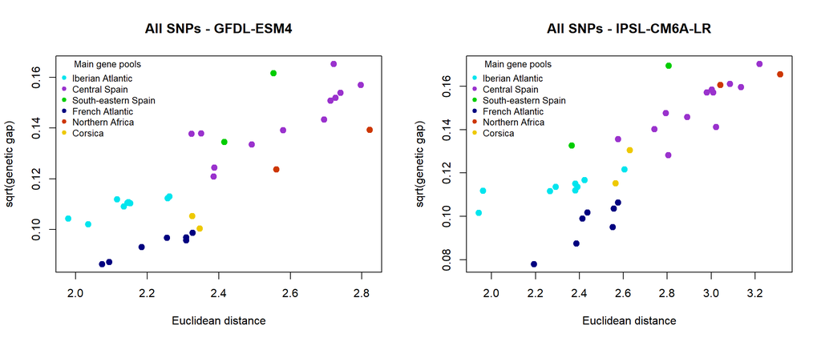

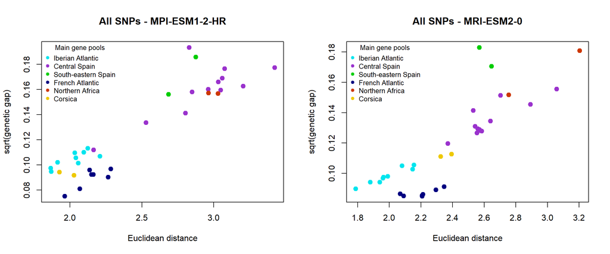

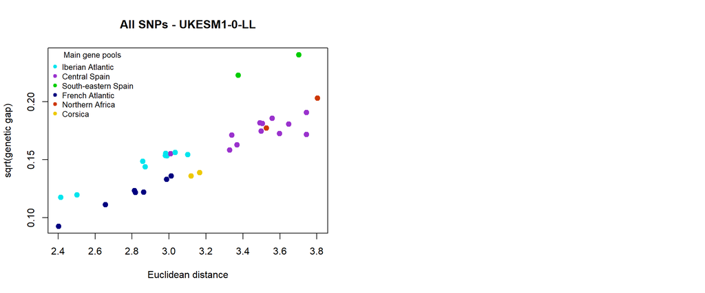

```r
 par(mfrow=c(1,2))

# plot the squared root of the genetic gap vs Euclidean environmental distance
lapply(list_g_gap, function(x){

  make_eucli_plot(X = x$dist_env,
          Y = sqrt(x$g_gap_allsnp$offset),
          colors = gps$color_main_gp_pop,
          color_names = gps$main_gp_pop,
          ylab = "sqrt(genetic gap)",
          plot_title = paste0("All SNPs - ",x$gcm))
})
```

## 5.3 Genetic gap estimation with sets of SNPs

We estimate the genetic gap for two sets of SNPs:

- the 188 candidate SNPs
- 188 randomly selected SNPs, which were sampled from the list of SNP names that does not include the candidate SNP names.

```r
# we sample random SNPs (same number of random SNPs as the number of candidate SNPs)
# and the random SNPs cannot be among the candidate SNPs (they are sampled from the list of SNP names after having removed the candidate SNP names)
set.seed(44)
rand_snps <- names(geno)[!names(geno) %in% candidates] %>%
  sample(length(candidates), replace=FALSE)

list_snpsets <- list(candidates = list(set_name = "Candidate SNPs",
                                       snp_names = candidates,
                                       snp_numbers =  which(names(geno) %in% candidates)),
                     control = list(set_name = "Random SNPs",
                                    snp_names = rand_snps,
                                    snp_numbers = which(names(geno) %in% rand_snps)))
```

```r
list_g_gap <- lapply(list_g_gap, function(y){

y$g_gap_snpsets <- lapply(list_snpsets, function(x) {

x$g_gap <- genetic.gap(input = geno,
                       env = clim_past,
                       pred.env = y$clim_fut,
                       candidate.loci = x$snp_numbers,
                       K = 5)
return(x)
})

return(y)
})
```

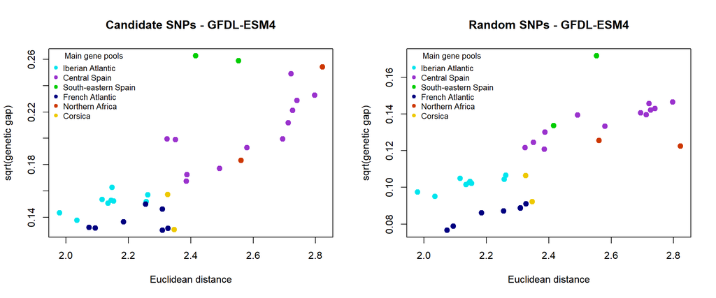

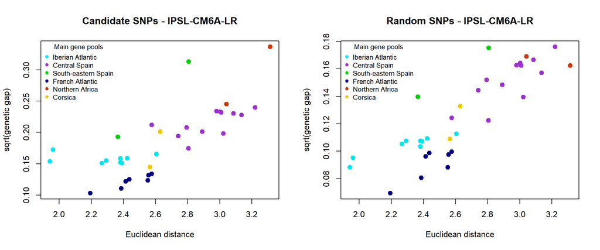

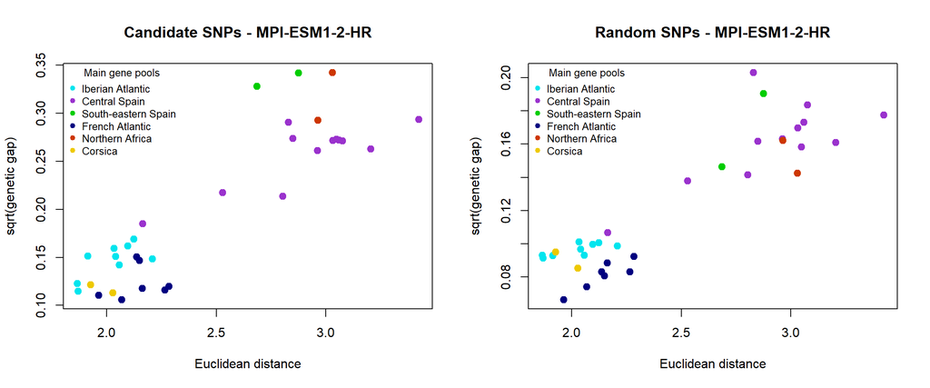

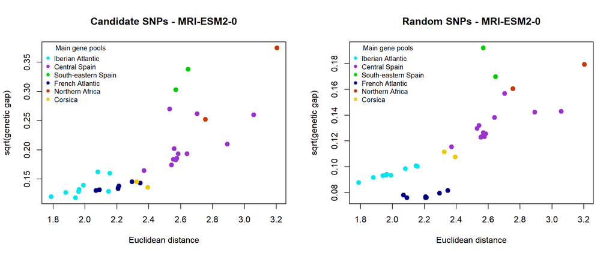

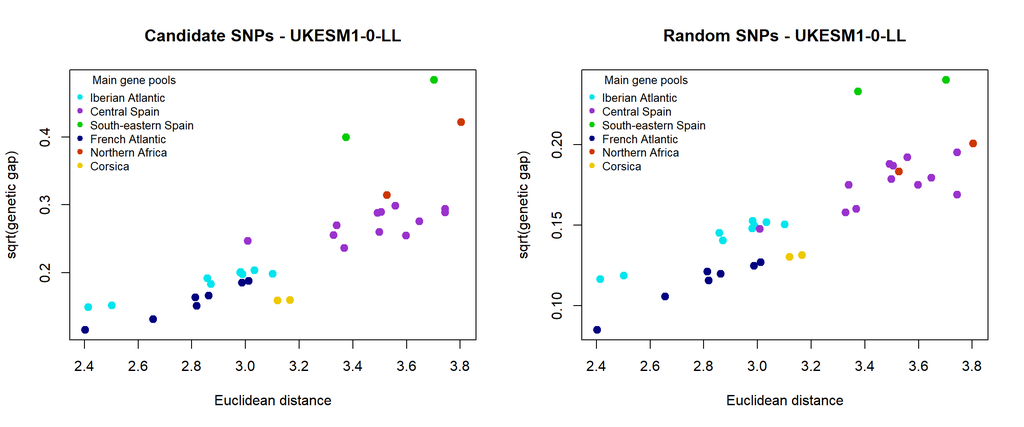

```r
par(mfrow=c(1,2))
lapply(list_g_gap, function(y){

lapply(y$g_gap_snpsets, function(x) make_eucli_plot(
  X = y$dist_env,
  Y = sqrt(x$g_gap$offset),
  colors = gps$color_main_gp_pop,
  color_names = gps$main_gp_pop,
  ylab = "sqrt(genetic gap)",
  plot_title = paste0(x$set_name," - ",y$gcm)))

})
```

Let’s look the the barplots of the eigenvalues.

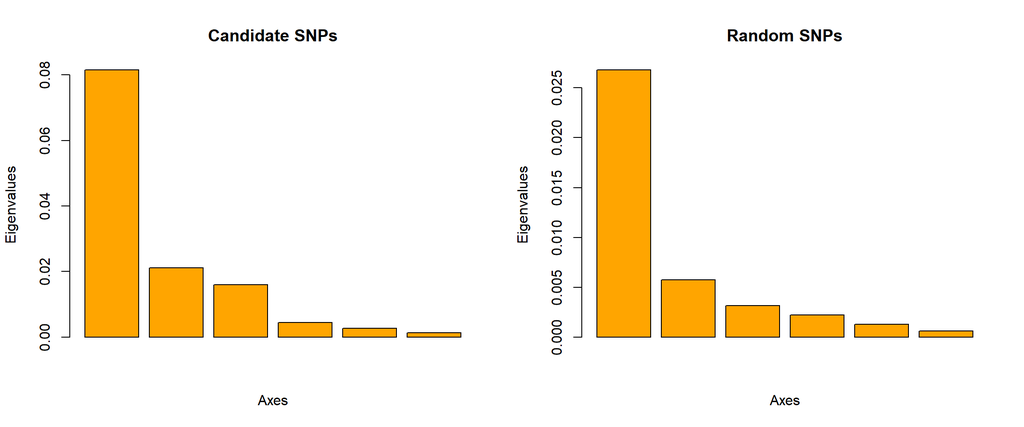

```r
par(mfrow=c(1,2))

lapply(list_g_gap[[1]]$g_gap_snpset, function(x)
barplot(x$g_gap$eigenvalues, col = "orange", xlab = "Axes", ylab = "Eigenvalues",main=x$set_name))
```

Correlations between the squared Euclidean climatic distance and the genetic gap:

```r
lapply(list_g_gap, function(y){
  lapply(y$g_gap_snpsets, function(x){

cor(unique(x$g_gap$offset),unique(y$dist_env^2))

  }) %>% bind_rows()

}) %>%
  bind_rows(.id="GCM") %>%
  kable_mydf()
```

| GCM | candidates | control |
| --- | --- | --- |
| GFDL-ESM4 | 0.78 | 0.79 |
| IPSL-CM6A-LR | 0.74 | 0.86 |
| MPI-ESM1-2-HR | 0.86 | 0.89 |
| MRI-ESM2-0 | 0.77 | 0.79 |
| UKESM1-0-LL | 0.75 | 0.82 |

# 6 Corrected allele frequencies

In a similar way to Gain et al. (2023) and Capblancq et al. (2023), we want to use **allele frequencies corrected for population structure** in the Gradient Forest analysis. Here we use the outputs from a latent factor mixed model (LFMM) to extract the corrected allele frequencies.

To understand, here the model applied by the `lfmm2` function:

$$\mathbf{Y}_{fit} = \mathbf{XB}^T + \mathbf{UV}^T$$
where $\mathbf{B}$, $\mathbf{U}$ and $\mathbf{V}$ are the effect size, and factor and loading matrices adjusted by the `lfmm2` algorithm from the set of current environmental variables included in the matrix $\mathbf{X}$. $\mathbf{B}$ is a matrix of dimension $p \times b$, with $p$ the number of genetic markers and $b$ the number of environmental variables. $\mathbf{U}$ is a matrix of dimension $n \times K$, with $n$ the number of individuals (ie genotypes) and $K$ the number of latent factors. $\mathbf{V}$ is a matrix of dimension $p \times K$. $\mathbf{X}$ is a matrix of dimension $n \times b$. $\mathbf{Y}_{fit}$ is a matrix of dimension $n \times p$.

We want a matrix of allele frequencies corrected for population structure, so basically:

$$\mathbf{Y}_{corrected} = \mathbf{Y}_{fit} - \mathbf{UV}^T = \mathbf{XB}^T$$
Below, we do the matrix multiplication of the matrix $\mathbf{X}$ (dimension $n \times b$) and the transpose of the matrix $\mathbf{B}$ (dimension $b \times p$) to obtain the matrix $\mathbf{Y}_{corrected}$ (dimension $n \times p$).

```r
# we load the imputed genomic data with allele counts (and with MAF)
geno_withmaf <-  read.csv(here("data/DryadRepo/ImputedGenomicData_AlleleCounts_withmaf.csv")) %>%
  column_to_rownames("snp_ID") %>%
  t()

# We run LFMM
mod_withmaf <- lfmm2(input = geno_withmaf,
                     env = as.matrix(clim_past),
                     K = 5,
                     effect.sizes = T) # to return the matrix B (the matrix of effect sizes)

# Matrix multiplication of matrix X and the transpose of matrix B
geno_corrected <- as.matrix(clim_past) %*% t(mod_withmaf@B) %>%
  set_rownames(rownames(geno_withmaf)) %>%
  as.data.frame() %>%
  rownames_to_column(var="clon")

# save the matrix for future analyses with and without MAF
geno_corrected %>% write_csv(here("data/DryadRepo/CorrectedAlleleFrequencies_withmaf.csv"))

geno_corrected %>%
  dplyr::select(clon,all_of(colnames(geno))) %>%
  write_csv(here("data/DryadRepo/CorrectedAlleleFrequencies_withoutmaf.csv"))

geno_corrected[1:10,1:10] %>%
  kable_mydf(boldfirstcolumn = 1)
```

| clon | snp_1 | snp_2 | snp_3 | snp_4 | snp_5 | snp_6 | snp_7 | snp_8 | snp_9 |
| --- | --- | --- | --- | --- | --- | --- | --- | --- | --- |
| ALT10 | 0.01 | 0 | 0.12 | -0.02 | 0.07 | 0.14 | 0.02 | -0.01 | -0.04 |
| ALT2 | 0.01 | 0 | 0.12 | -0.02 | 0.07 | 0.14 | 0.02 | -0.01 | -0.04 |
| ALT3 | 0.01 | 0 | 0.12 | -0.02 | 0.07 | 0.14 | 0.02 | -0.01 | -0.04 |
| ALT4 | 0.01 | 0 | 0.12 | -0.02 | 0.07 | 0.14 | 0.02 | -0.01 | -0.04 |
| ALT5 | 0.01 | 0 | 0.12 | -0.02 | 0.07 | 0.14 | 0.02 | -0.01 | -0.04 |
| ALT6 | 0.01 | 0 | 0.12 | -0.02 | 0.07 | 0.14 | 0.02 | -0.01 | -0.04 |
| ALT8 | 0.01 | 0 | 0.12 | -0.02 | 0.07 | 0.14 | 0.02 | -0.01 | -0.04 |
| ALT9 | 0.01 | 0 | 0.12 | -0.02 | 0.07 | 0.14 | 0.02 | -0.01 | -0.04 |
| ARM1 | 0.01 | 0 | 0.14 | -0.04 | 0.07 | 0.14 | 0.00 | -0.01 | -0.06 |
| ARM10 | 0.01 | 0 | 0.14 | -0.04 | 0.07 | 0.14 | 0.00 | -0.01 | -0.06 |

## References

Capblancq, Thibaut, Susanne Lachmuth, Matthew C Fitzpatrick, and Stephen R Keller. 2023. “From Common Gardens to Candidate Genes: Exploring Local Adaptation to Climate in Red Spruce.” *New Phytologist* 237 (5): 1590–1605.

Caye, Kevin, Basile Jumentier, Johanna Lepeule, and Olivier François. 2019. “LFMM 2: Fast and Accurate Inference of Gene-Environment Associations in Genome-Wide Studies.” *Molecular Biology and Evolution* 36 (4): 852–60.

Frichot, Eric, Sean D Schoville, Guillaume Bouchard, and Olivier François. 2013. “Testing for Associations Between Loci and Environmental Gradients Using Latent Factor Mixed Models.” *Molecular Biology and Evolution* 30 (7): 1687–99.

Gain, Clément, and Olivier François. 2021. “LEA 3: Factor Models in Population Genetics and Ecological Genomics with r.” *Molecular Ecology Resources* 21 (8): 2738–48.

Gain, Clément, Benedicte Rhone, Philippe Cubry, Israfel Salazar, Florence Forbes, Yves Vigouroux, Flora Jay, and Olivier François. 2023. “A Quantitative Theory for Genomic Offset Statistics.” *bioRxiv*, 2023–01.

Jaramillo-Correa, Juan-Pablo, Isabel Rodrı́guez-Quilón, Delphine Grivet, Camille Lepoittevin, Federico Sebastiani, Myriam Heuertz, Pauline H Garnier-Géré, et al. 2015. “Molecular Proxies for Climate Maladaptation in a Long-Lived Tree (Pinus Pinaster Aiton, Pinaceae).” *Genetics* 199 (3): 793–807.

Pritchard, Jonathan K, Matthew Stephens, and Peter Donnelly. 2000. “Inference of Population Structure Using Multilocus Genotype Data.” *Genetics* 155 (2): 945–59.